# OpenRefine

## Tentative schedule

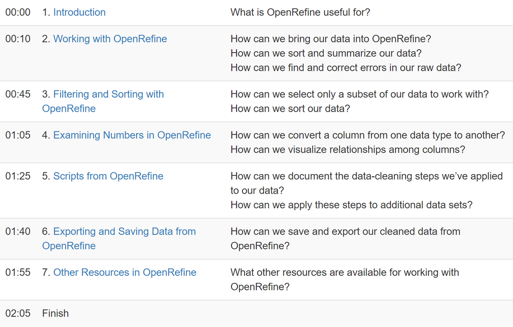

## 1. Introduction (10’)

### What is OpenRefine useful for?

- Free, open source tool for data cleaning.
- Can do challenging cleaning easily.
- Tracks history automatically.

## 2. Working with OpenRefine (35’)

- *How can we bring our data into OpenRefine?*
- *How can we sort and summarize our data?*
- *How can we find and correct errors in our raw data?*

## Create a project

### Import Portal_rodents_19772002_scinameUUIDs.csv

[figure not shown]

## Create a project

### Play with preview

[figure not shown]

## Create a Text facet on scientificName

### Facet > Text facet

[figure not shown]

## Create a Text facet on scientificName

1. Sort by name and by count. Can you spot any problem?
2. Hover over names to reveal the edit function
   - Fix something everywhere, then undo.

[figure not shown]

## Exercise

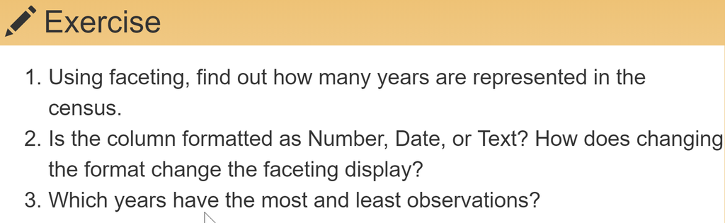

## Solution

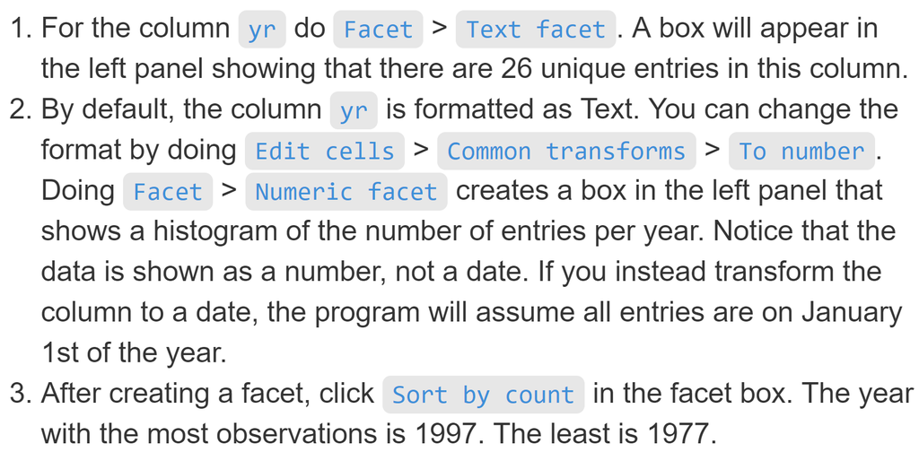

## Cluster scientificName to clean it

- Merge using metaphone3 (should identify three clusters).
- Try different Methods but don’t Merge again.

[figure not shown]

## Split columns

Split `scientificName` into genus and species:

- Edit Column > Split into several columns…

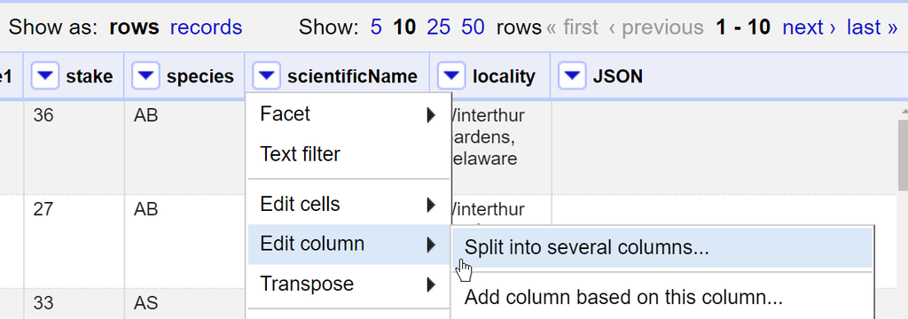

## Split columns

- replace the comma with a space.
- Uncheck “Remove this column”.

(There is a problem with leading white space. See next.)

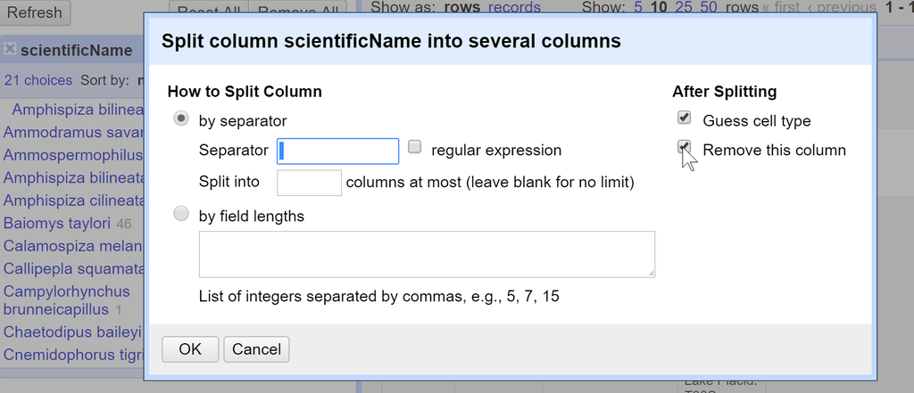

## Trim whitespace

- Undo previous split, trim whitespace, an repeat split.

(**Finally undo to leave the dataset unsplit**.)

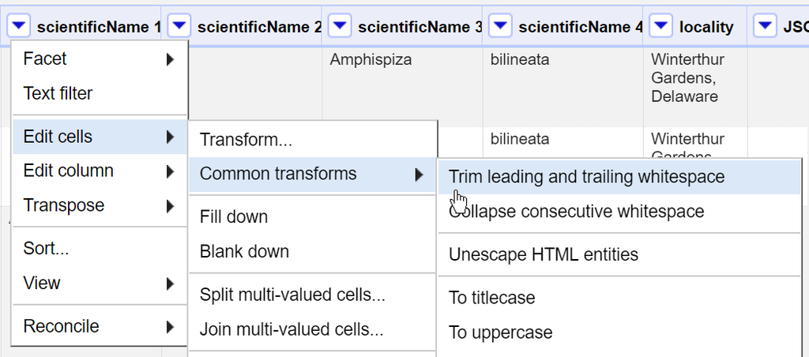

## Exercise

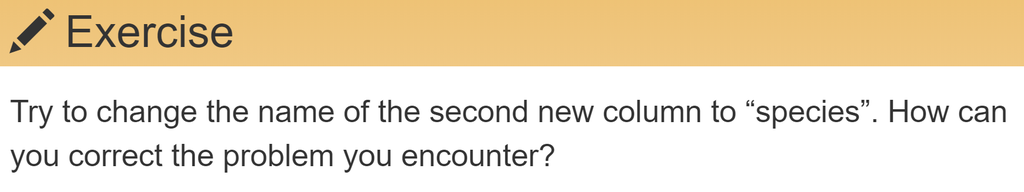

## Solution

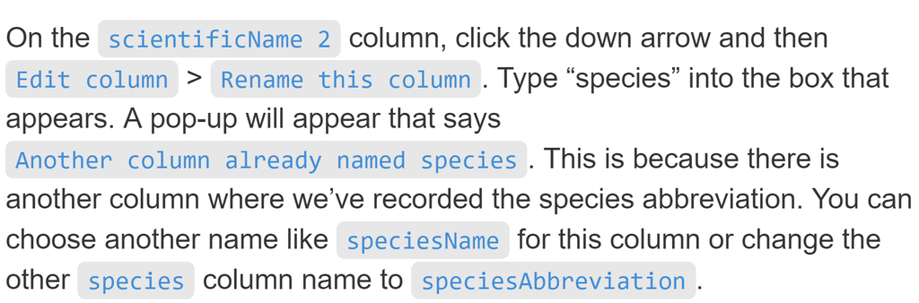

## Key points

Facet and cluster your data to identify errors or outliers.

## 3. Filtering and Sorting (20’)

- *How can we select specific subsets of data?*
- *How can we sort our data?*

## Exercise

- Filter the scientificNames matching “bai”.
- Type more characters.
- Click on each species’ name; and on *include / exclude*.

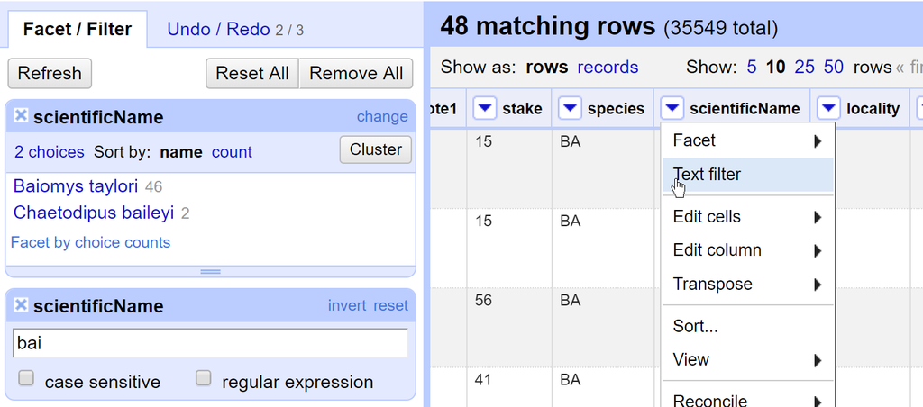

## Exercise

### Sorting by one column

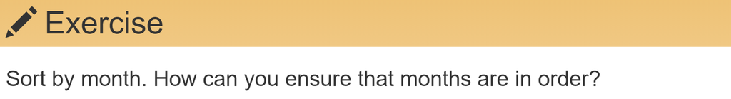

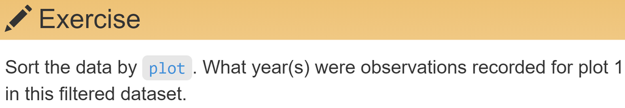

## Exercise

### Sorting by multiple columns

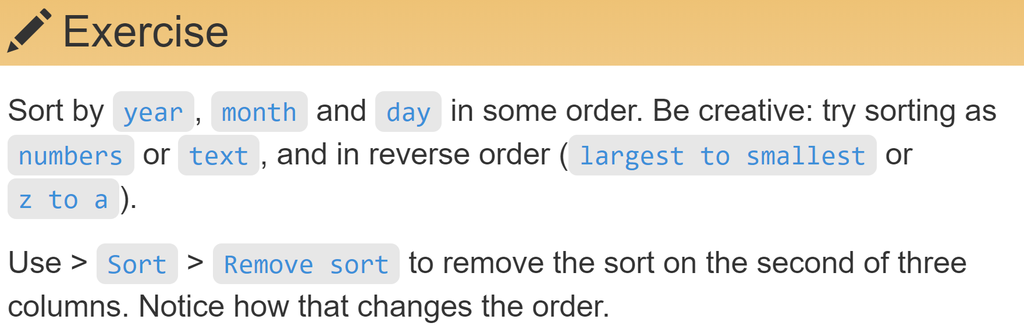

## Key point

Sorting and filtering with Openrefine keeps raw data raw.

## 4. Examining Numbers (20’)

- *How can we change the type of a column?*
- *How can we visualize relationships among columns?*

## Change type of `recordID` to number

(**First remove any facet.**)

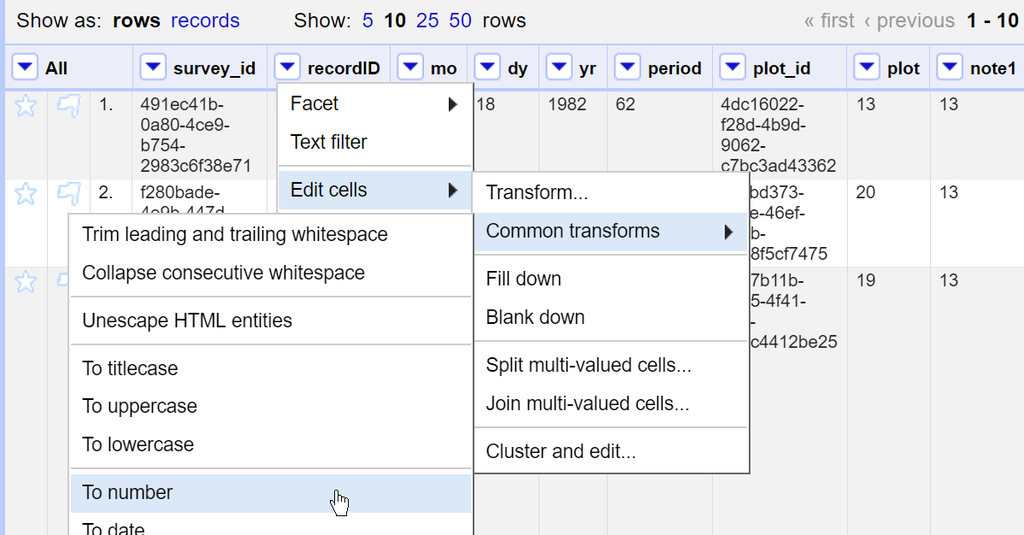

## Exercise

### Numeric facet

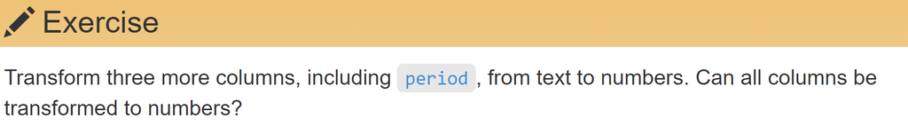

## Exercise

### Numeric facet

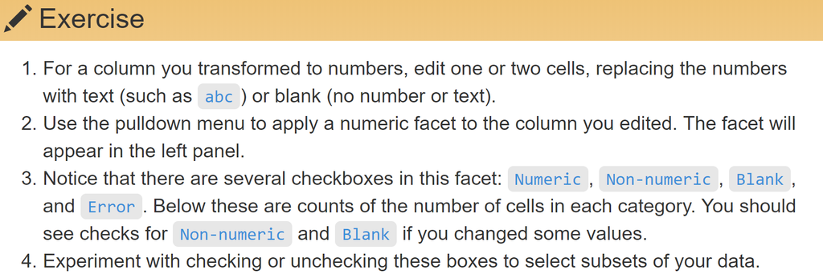

## Create a Scatterplot facet on `recordID`

(**`recordID`, `period`, and 2 other columns should be numbers**)

[figure not shown]

## Exercise

### Explore ralationship among numeric columns

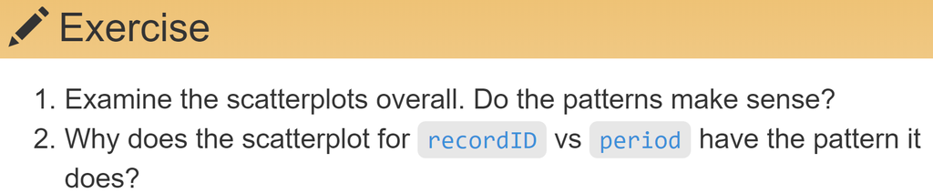

## Exercise

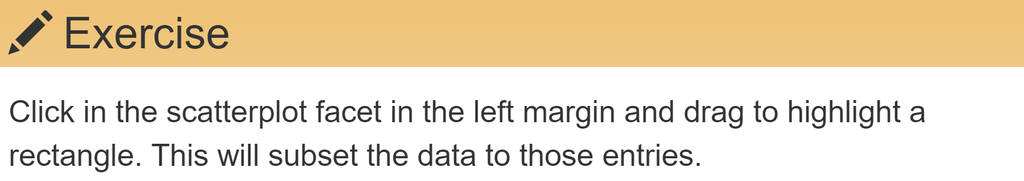

## Exercise

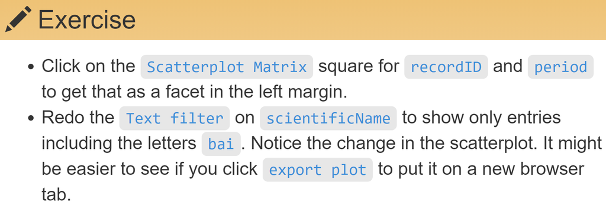

## Key point

OpenRefine helps you overview numerical data.

## 5. Scripts from OpenRefine (15’)

- *How can we document the data-cleaning steps?*
- *How can we apply these steps to other datasets?*

## Export scripts of your work history

### Undo / Redo > Extract…

- OpenRefine scripts your history.
- You can extract and save it as plain text.

[figure not shown]

## Export scripts of your work history

### Undo / Redo > Apply…

- You can apply stored cleaning steps to other datasets with the same structure.

[figure not shown]

## Key points

- You can reproduce your cleaning steps.
- You can publish in an appendix your data-cleaning steps.

## 6. Exporting and Saving Data (15’)

### How can we save and export our cleaned data from OpenRefine?

## Export clean datasets or entire projects

[figure not shown]

## Key points

You can export and share cleaned data, or entire projects.

## 7. Other Resources in OpenRefine

### What other resources are available for working with OpenRefine?

[Learn more](https://datacarpentry.org/OpenRefine-ecology-lesson/06-resources/index.html)

## End

### Have you installed the software for the next lesson?